# Exploratory Analysis of Text Data for Swiftkey Capstone Project

Anna Korsakova Bain

December 29, 2015

In order to create a predictive text model for the Coursera Swiftkey project, I am working with a large corpus of documents obtained from publicly available data; more specifically blogs, Twitter, and news feeds. The raw data can be found here: https://d396qusza40orc.cloudfront.net/dsscapstone/dataset/Coursera-SwiftKey.zip.

The goal of this milestone report is to demonstrate an understanding of the raw data as well as the ability to acquire and cleanse it. I will also outline the exploratory analysis that I have performed in order to understand the relationship and distribution within the types of data available in the corpora (i.e. words, tokens, and phrases).

### Data Acquisition and Cleaning

#### Loading Libraries and Setting up the Environment

```r
  Sys.setenv(JAVA_HOME='C:\\Program Files\\Java\\jre1.8.0_66')
  gc()

  library(tm)
  library(wordcloud)
  library(RWeka)
  library(ggplot2)
  library(dplyr)
  library(stringi)

  setwd("D:/DataScienceCertification/Capstone/final/en_US")
  set.seed(6384)

  sample_data1 <- vector(mode="character")
```

#### Creating Functions to be Used throughout the Program

```r
  #This function will read 10,000 lines from each of the 3 English files
  #and randomly select approximately 5k records from each, concatenating the three samples togehter
  create_sample <- function(sd) {
    for (i in 1:10000) {
      if (rbinom(1, 1, 0.5))
        sd <- c(sd, readLines(twitter_con, 1))
    }

    for (i in 1:10000 ) {
      if (rbinom(1, 1, 0.5))
        sd <- c(sd, readLines(news_con, 1))
    }


    for (i in 1:10000 ) {
      if (rbinom(1, 1, 0.5))
        sd <- c(sd, readLines(blog_con, 1))
    }
    return(sd)
  }

  #This function changes the encoding of our sample to ASCII as well load a
  #profanity list from Shutterstock and use it to clean our sample
  clean_data <- function(sd) {
    sd<-iconv(sd, to="ASCII", sub = "")

    profanity <- read.csv("ShutterStock.csv", stringsAsFactors = FALSE)
    sd <- gsub(paste(profanity$word, collapse = "|"), "", sd, ignore.case=TRUE)

    return(sd)
  }

  #This function tokenizes the sample data into a text corpus and further cleanses, removing numbers
  #whitespace, capitalization, and multiple white spaces
  tokenize_data <- function(sd) {
    text_corpus <- Corpus(VectorSource(sd), readerControl = list(language = "en"))

    text_corpus <- tm_map(text_corpus, removeNumbers)
    text_corpus <- tm_map(text_corpus, removePunctuation)
    text_corpus <- tm_map(text_corpus , stripWhitespace)
    text_corpus <- tm_map(text_corpus, tolower)
    text_corpus <- tm_map(text_corpus, PlainTextDocument)

    return(text_corpus)
  }

  #This function performs the same functionality as tokenize_data, with the exception of one
  #extra step - to remove stopwords
  tokenize_data_rm_stopwords <- function(sd) {
    text_corpus <- Corpus(VectorSource(sd), readerControl = list(language = "en"))
    text_corpus <- tm_map(text_corpus, removeNumbers)
    text_corpus <- tm_map(text_corpus, removePunctuation)
    text_corpus <- tm_map(text_corpus , stripWhitespace)
    text_corpus <- tm_map(text_corpus, tolower)
    text_corpus <- tm_map(text_corpus, PlainTextDocument)
    text_corpus <- tm_map(text_corpus, removeWords, stopwords("english"))

    return(text_corpus)
  }

  #This function creates a Document Term Matrix
  create_termMatrix <- function(tc) {
    dtm <- DocumentTermMatrix(tc)
    return(dtm)
    }
```

#### Gathering a Basic Understanding of the Data

```r
  #Getting some info on the data files
  blogs <- readLines("en_US.blogs.txt")
  news <- readLines("en_US.news.txt")
  twitter <- readLines("en_US.twitter.txt")

  #Size of each file
  file.info("en_US.blogs.txt")$size / 1024^2
```

```
## [1] 200.4242
```

```r
  file.info("en_US.news.txt")$size / 1024^2
```

```
## [1] 196.2775
```

```r
  file.info("en_US.twitter.txt")$size / 1024^2
```

```
## [1] 159.3641
```

```r
  #Length of each file
  length(blogs)
```

```
## [1] 899288
```

```r
  length(news)
```

```
## [1] 77259
```

```r
  length(twitter)
```

```
## [1] 2360148
```

```r
  #Getting stats such as word counts
  stri_stats_latex(blogs)
```

```
##     CharsWord CharsCmdEnvir    CharsWhite         Words          Cmds
##     163325412             9      43302825      37865888             3
##        Envirs
##             0
```

```r
  stri_stats_latex(news)
```

```
##     CharsWord CharsCmdEnvir    CharsWhite         Words          Cmds
##      12502954             0       3114374       2665742             0
##        Envirs
##             0
```

```r
  stri_stats_latex(twitter)
```

```
##     CharsWord CharsCmdEnvir    CharsWhite         Words          Cmds
##     125769312          3033      36047904      30578891           963
##        Envirs
##             0
```

```r
  #Longest entry
  max(nchar(blogs))
```

```
## [1] 40835
```

```r
  max(nchar(news))
```

```
## [1] 5760
```

```r
  max(nchar(twitter))
```

```
## [1] 213
```

```r
  #Removing the large character vectors
  rm(blogs)
  rm(news)
  rm(twitter)
```

#### Loading, Cleaning, and Tokenizing the Data

```r
  #Setting up the connections
  twitter_con <- file("en_US.twitter.txt", "r")
  news_con <- file("en_US.news.txt", "r")
  blog_con <- file("en_US.blogs.txt", "r")

  #Creating the sample dataset
  sample_data1 <- create_sample(sample_data1)

  #Removing the connections
  remove(blog_con)
  remove(twitter_con)
  remove(news_con)

  #Data cleaning
  sample_data1 <- clean_data(sample_data1)

  #Data tokenization
  corp1 <- tokenize_data(sample_data1)
  corp1_wo_stopwords <- tokenize_data_rm_stopwords(sample_data1)

  #Creation of the document term matrices
  dtm1 <- create_termMatrix(corp1)
  dtm1_wo_stopwords <- create_termMatrix(corp1_wo_stopwords)
```

### Exploratory Analysis

#### Some words are more frequent than others - what are the distributions of word frequencies?

In order to understand word frequencies, I decided to work with both sets of data created during my Data Acquisition and Cleaning phase: the corpus which includes stopwords and the corpus without stopwords.

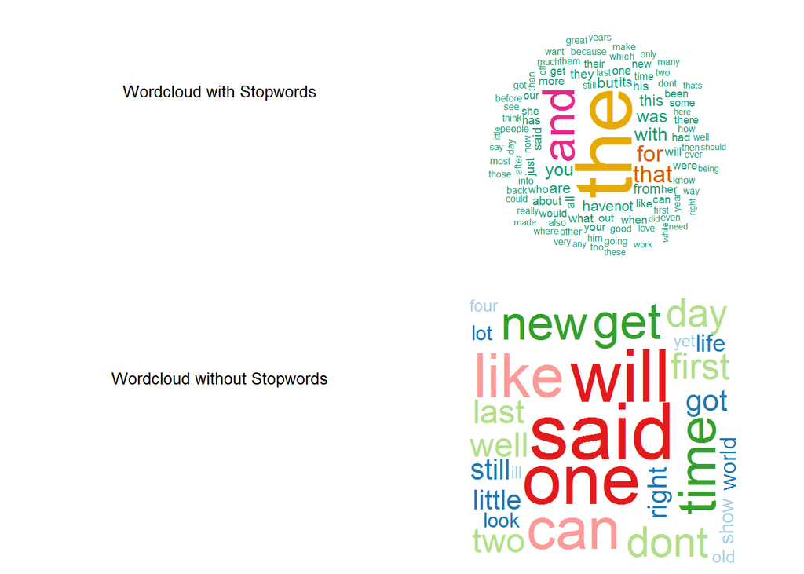

```r
  #Wordcloud graphs
  layout(matrix(c(1, 2, 3, 4), nrow=2))
  plot.new()
  text(x=0.5, y=0.9, "Wordcloud with Stopwords")
  plot.new()
  text(x=0.5, y=0.9, "Wordcloud without Stopwords")
  wordcloud(corp1, min.freq = 350, scale=c(5,0.5), random.order = FALSE, colors=brewer.pal(6, "Dark2"))
  wordcloud(corp1_wo_stopwords, min.freq = 150, scale=c(5,0.5), random.order = FALSE, colors=brewer.pal(6, "Paired"))
```

#### Top 20 Most Frequently Used Words

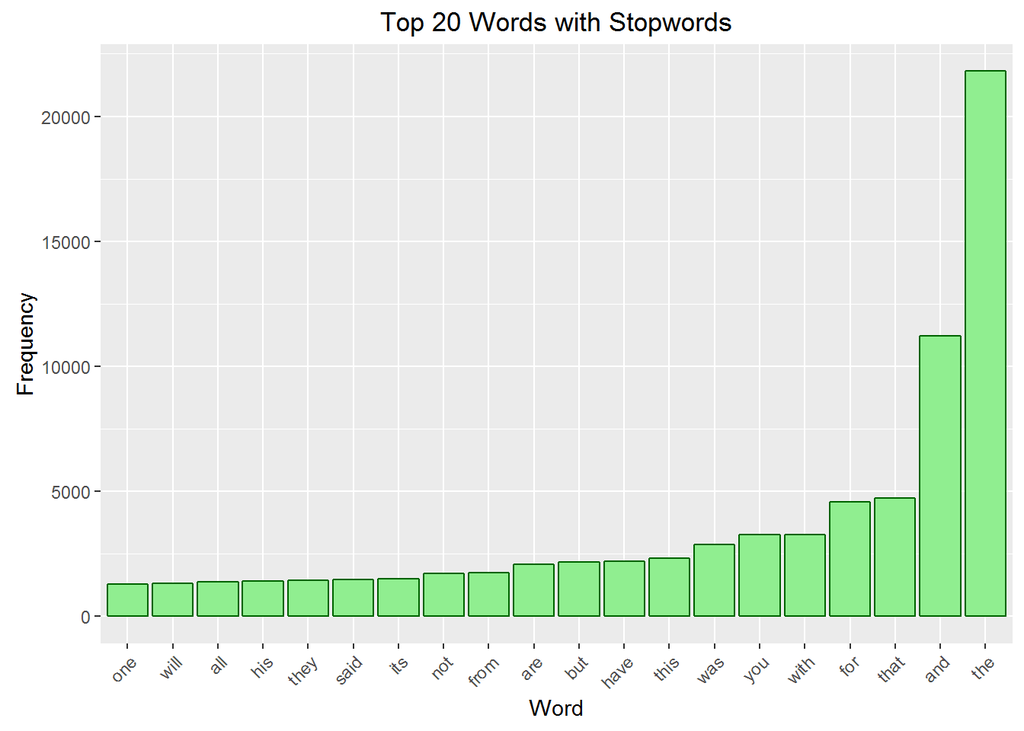

```r
  #Find the most frequent words in the Document Text Matrix
  termFreq <- sort(colSums(as.matrix(dtm1)), decreasing=TRUE)
  termFreq <-subset(termFreq, termFreq>=1250)

  #Find the most frequent words in the Document Text Matrix - without Stopwords
  termFreq_wo_stopwrods <- sort(colSums(as.matrix(dtm1_wo_stopwords)), decreasing=TRUE)
  termFreq_wo_stopwrods <-subset(termFreq_wo_stopwrods, termFreq_wo_stopwrods>=531)

  one_word_df <- data.frame(word=names(termFreq), freq=termFreq)
  one_word_wo_stopwords_df <- data.frame(word=names(termFreq_wo_stopwrods), freq=termFreq_wo_stopwrods)

  p <- ggplot(one_word_df, aes(reorder(word, freq), freq))
  p <- p + geom_bar(stat="identity", fill="lightgreen", colour="darkgreen")
  p <- p + theme(axis.text.x=element_text(angle=45, hjust=1))
  p <- p + labs(title = "Top 20 Words with Stopwords")
  p <- p + ylab("Frequency")  + xlab("Word")
  p
```

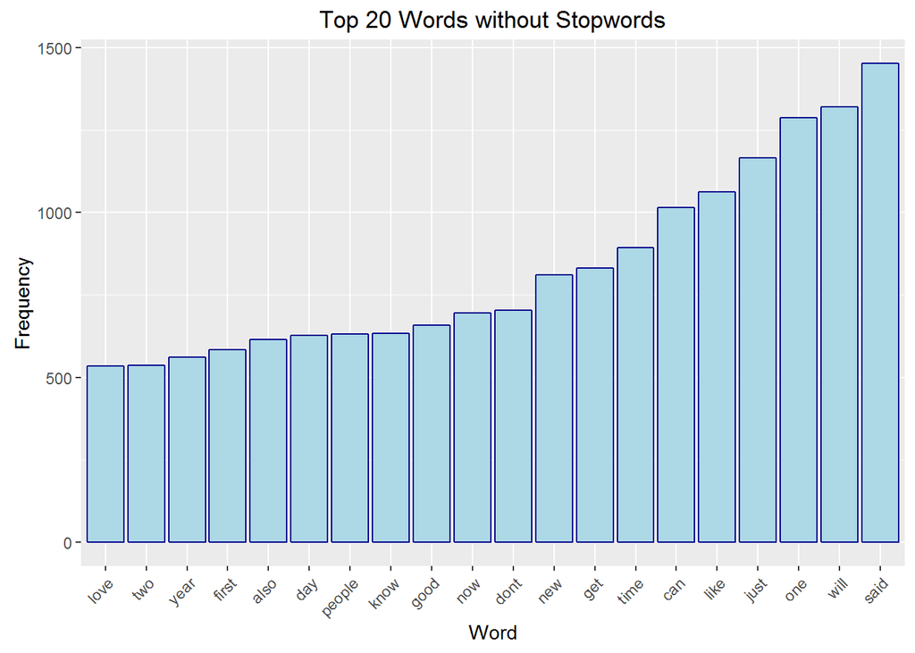

```r
  q <- ggplot(one_word_wo_stopwords_df, aes(reorder(word, freq), freq))
  q <- q + geom_bar(stat="identity", fill="lightblue", colour="darkblue")
  q <- q + theme(axis.text.x=element_text(angle=45, hjust=1))
  q <- q + labs(title = "Top 20 Words without Stopwords")
  q <- q + ylab("Frequency")  + xlab("Word")
  q
```

#### What are the frequencies of 2-grams and 3-grams in the dataset?

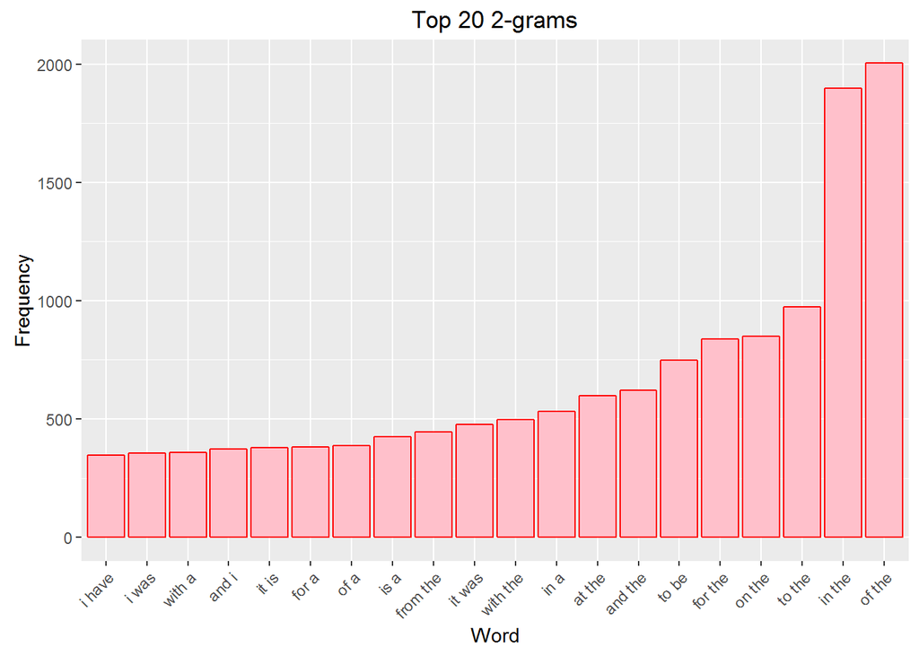

```r
  #Time to create Ngrams
  df<-data.frame(text=unlist(sapply(corp1, `[`, "content")), stringsAsFactors=F)
  df_wo_stopwords<-data.frame(text=unlist(sapply(corp1_wo_stopwords, `[`, "content")), stringsAsFactors=F)

  #Creating 2 and 3-grams
  two_ngram <- NGramTokenizer(df, Weka_control(min = 2, max = 2, delimiters = " \\r\\n\\t.,;:\"()?!"))
  three_ngram <- NGramTokenizer(df, Weka_control(min = 3, max = 3, delimiters = " \\r\\n\\t.,;:\"()?!"))

  #Gathering the most frequently used ngrams
  df_two <- as.data.frame(table(two_ngram))
  df_two <- subset(arrange(df_two, desc(Freq)), Freq >= 340)
  df_three <- as.data.frame(table(three_ngram))
  df_three <- subset(arrange(df_three, desc(Freq)), Freq >= 46)

  #plotting most frequently used words
  p <- ggplot(df_two, aes(reorder(two_ngram, Freq), Freq))
  p <- p + geom_bar(stat="identity", fill="pink", colour="red")
  p <- p + theme(axis.text.x=element_text(angle=45, hjust=1))
  p <- p + labs(title = "Top 20 2-grams")
  p <- p + ylab("Frequency")  + xlab("Word")
  p
```

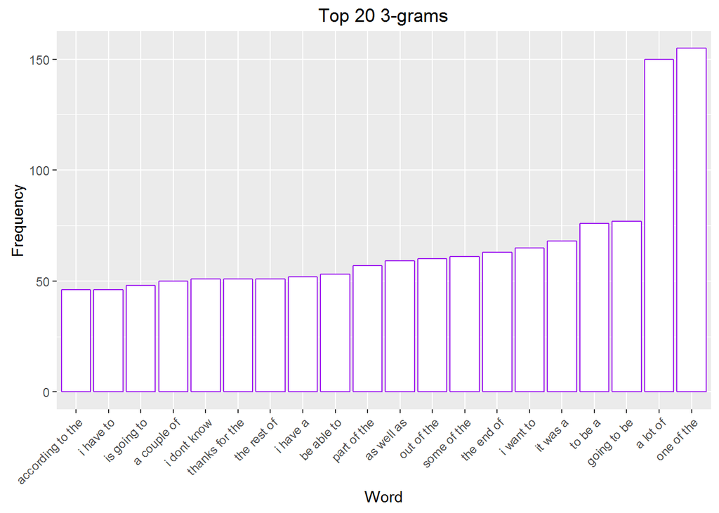

```r
  q <- ggplot(df_three, aes(reorder(three_ngram, Freq), Freq))
  q <- q + geom_bar(stat="identity", fill="white", colour="purple")
  q <- q + theme(axis.text.x=element_text(angle=45, hjust=1))
  q <- q + labs(title = "Top 20 3-grams")
  q <- q + ylab("Frequency")  + xlab("Word")
  q
```

#### How many unique words do you need in a frequency sorted dictionary to cover 50% of all word instances in the language? 90%?

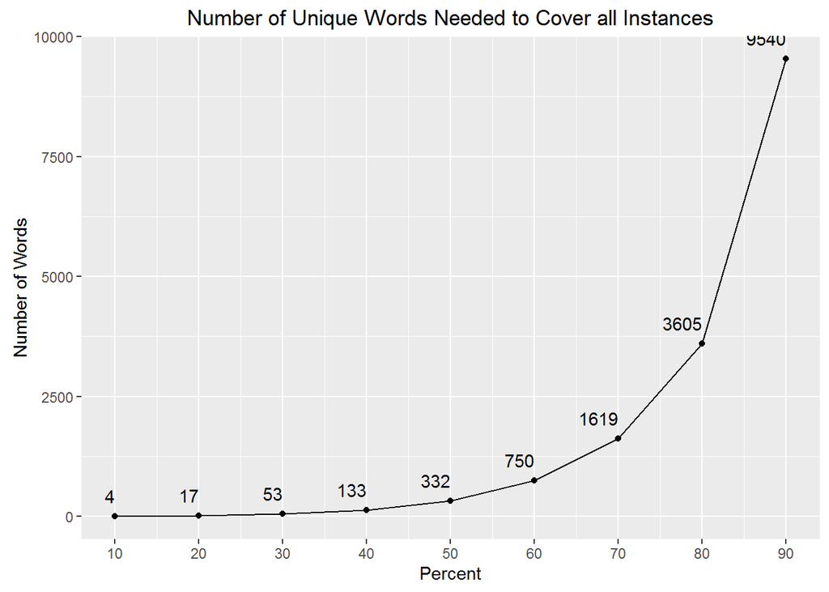

```r
  #Get the frequencies for each word
  termFreq <- sort(colSums(as.matrix(dtm1)), decreasing=TRUE)
  one_word_freq <- data.frame(word=names(termFreq), freq=termFreq)

  #This function will assist us in getting the number of words needed
  #to get to the required percentage
  get_num_words <- function(pct_needed) {
    i = 1
    pct = 0
    while (pct <= pct_needed){
      pct = pct + (one_word_freq$freq[i]/sum(one_word_freq$freq) * 100)
      i = i + 1
    }
    return(i)
  }

  #Create new dataframe with first row
  df_perc_freq <- data.frame(get_num_words(10))
  f <- 20

  while (f<100) {
    df_perc_freq <- rbind(df_perc_freq, get_num_words(f))
    f <- f+ 10
  }

  df_perc_freq <- cbind(df_perc_freq, c(10,20,30,40,50,60,70,80,90))
  colnames(df_perc_freq) <- c("numWords", "Pct")


  q <- qplot(df_perc_freq$Pct,df_perc_freq$numWords, geom=c("line","point"))
  q <- q <- q + labs(title = "Number of Unique Words Needed to Cover all Instances")
  q <- q + ylab("Number of Words") + xlab("Percent")
  q <- q + scale_x_continuous(breaks=c(10,20,30,40,50,60,70,80,90))
  q <- q + geom_text(aes(label=df_perc_freq$numWords), hjust=1, vjust=-1)
  q
```

#### Interesting Findings

There is a huge difference between the Document Term Matrix with stopwords and without. It will be interesting to see how a prediction model behaves using these two different sets of data.

#### How do you evaluate how many of the words come from foreign languages?

I think that by loading a well-known and used dictionary, we can eliminate foreign words as well as incorrectly typed words.

#### Can you think of a way to increase the coverage – identifying words that may not be in the corpora or using a smaller number of words in the dictionary to cover the same number of phrases?

I think one way to increase coverage and reduce the number of words in the dictionary is to first start prediction with the same dataset we have been using and overtime, adjust it to the user’s dictionary. This way, words and phrases that the user does not use can be removed, and frequently used ones can be stored.